# FE8828 Assignment for Exploratory Data Analysis

Xu Xinzhi <sub><Email:XXU026@e.ntu.edu.sg></sub>

Oct 2021

*Note: - The first three findings are from last assigment with some additional improvements and comments.

### Finding #1

Find the mean balance with respect to whether people have housing. Plot in terms of age.

```r
df1 <- bank %>%
  group_by(age,housing) %>%
  summarise(mean_bal = mean(balance))%>%
  # case_when is a function to deal multiple choices.
  mutate(age_group = case_when(
    age < 30 ~ "youth",
    age < 50 ~ "middle-age",
    age < 60 ~ "senior",
    TRUE ~ "elder" ))
## `summarise()` regrouping output by 'age' (override with `.groups` argument)
df1
```

```
## # A tibble: 115 x 4
## # Groups:   age [67]
##      age housing mean_bal age_group
##    <int> <chr>      <dbl> <chr>
##  1    19 no          394. youth
##  2    20 no          661. youth
##  3    21 no         2076  youth
##  4    21 yes        1020  youth
##  5    22 no         1606. youth
##  6    22 yes         246  youth
##  7    23 no         3352. youth
##  8    23 yes        1589. youth
##  9    24 no          554. youth
## 10    24 yes         661. youth
## # … with 105 more rows
```

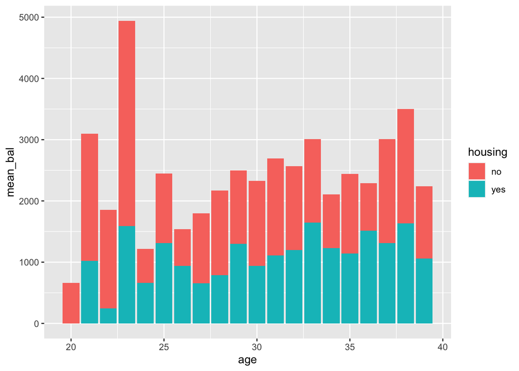

```r
filter(df1,age >=20 & age <40) %>%
ggplot(aes(x=age,y=mean_bal, fill=housing)) + geom_bar(stat="identity")
```

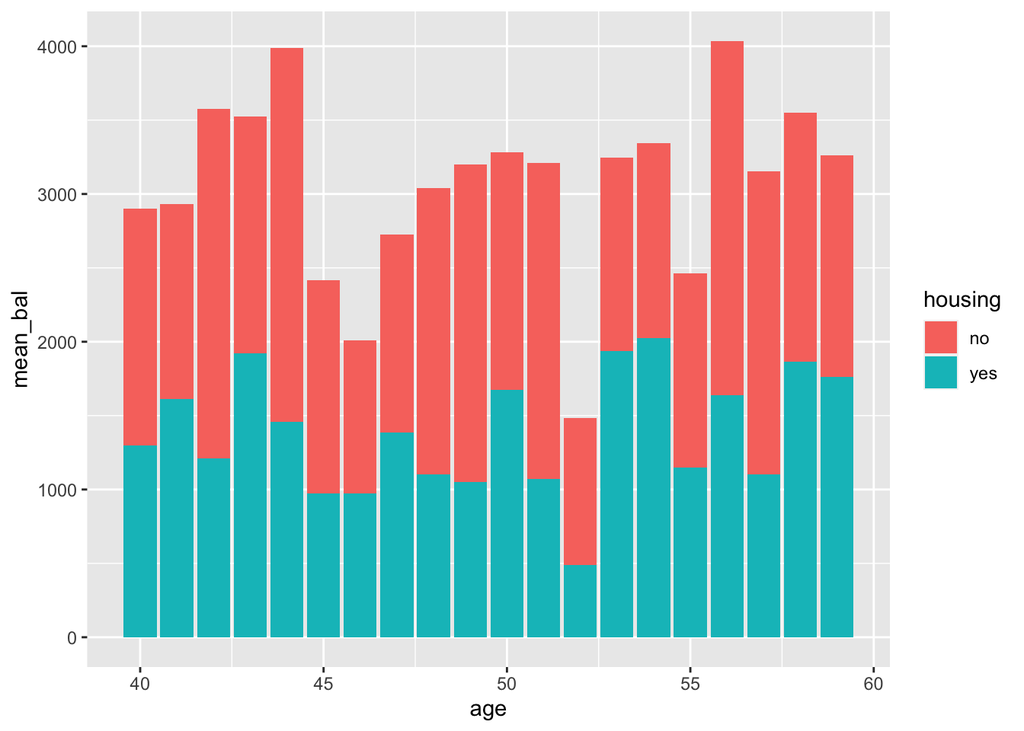

```r
filter(df1,age >=40 & age <60) %>%
ggplot(aes(x=age,y=mean_bal, fill=housing)) + geom_bar(stat="identity")
```

### Finding #2

Use 1,2,3,0 to represent education level of primary, secondary, tertiary and unknown respectively. Prob means the probability of default in each education group.

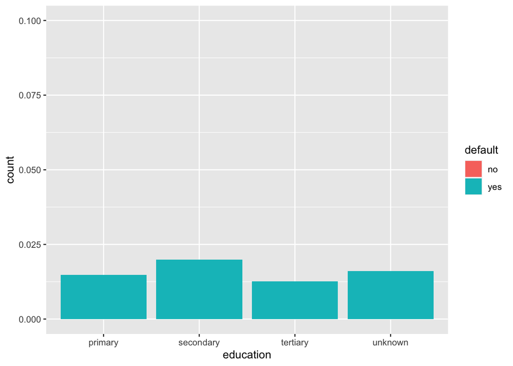

```r
bank %>%
  mutate(education = case_when(
    education == "primary" ~ 1,
    education == "secondary" ~ 2,
    education == "tertiary" ~ 3,
    education == "unknown" ~ 0
  )) %>%
  group_by(education, default)%>%
  summarise(n = n()) %>%
  mutate(prob = n / sum(n))
## `summarise()` regrouping output by 'education' (override with `.groups` argument)
## # A tibble: 8 x 4
## # Groups:   education [4]
##   education default     n   prob
##       <dbl> <chr>   <int>  <dbl>
## 1         0 no        184 0.984
## 2         0 yes         3 0.0160
## 3         1 no        668 0.985
## 4         1 yes        10 0.0147
## 5         2 no       2260 0.980
## 6         2 yes        46 0.0199
## 7         3 no       1333 0.987
## 8         3 yes        17 0.0126
ggplot(bank) +
  geom_bar(aes(x = education, fill = default), position = "fill")+
  ylim(0,0.1)
```

```r
#Because the percent of people with default record is too small, here I limit the ylim to 0-0.1 to have a clearer comparison between different education group.
```

We can see:

- People with secondary education have a lager probability of default while people with tertiary education default with the lowest probability.

### Finding #3

```r
distinct(bank,education)
```

```
##   education
## 1   primary
## 2 secondary
## 3  tertiary
## 4   unknown
```

```r
df <- bank %>%
  group_by(education) %>%
  filter(min_rank(balance) == 1 | min_rank(desc(balance)) == 1) %>%
  arrange(education,balance)
df
```

```
## # A tibble: 8 x 17
## # Groups:   education [4]
##     age job   marital education default balance housing loan  contact   day
##   <int> <chr> <chr>   <chr>     <chr>     <int> <chr>   <chr> <chr>   <int>
## 1    55 reti… married primary   no         -966 no      yes   cellul…    14
## 2    60 reti… married primary   no        71188 no      no    cellul…     6
## 3    51 entr… married secondary yes       -2082 no      yes   cellul…    28
## 4    75 reti… married secondary no        26452 no      no    teleph…    15
## 5    57 self… married tertiary  yes       -3313 yes     yes   unknown     9
## 6    42 entr… married tertiary  no        42045 no      no    cellul…     8
## 7    43 blue… married unknown   yes        -715 yes     no    unknown    30
## 8    51 hous… married unknown   no        21244 no      yes   cellul…     4
## # … with 7 more variables: month <chr>, duration <int>, campaign <int>,
## #   pdays <int>, previous <int>, poutcome <chr>, y <chr>
```

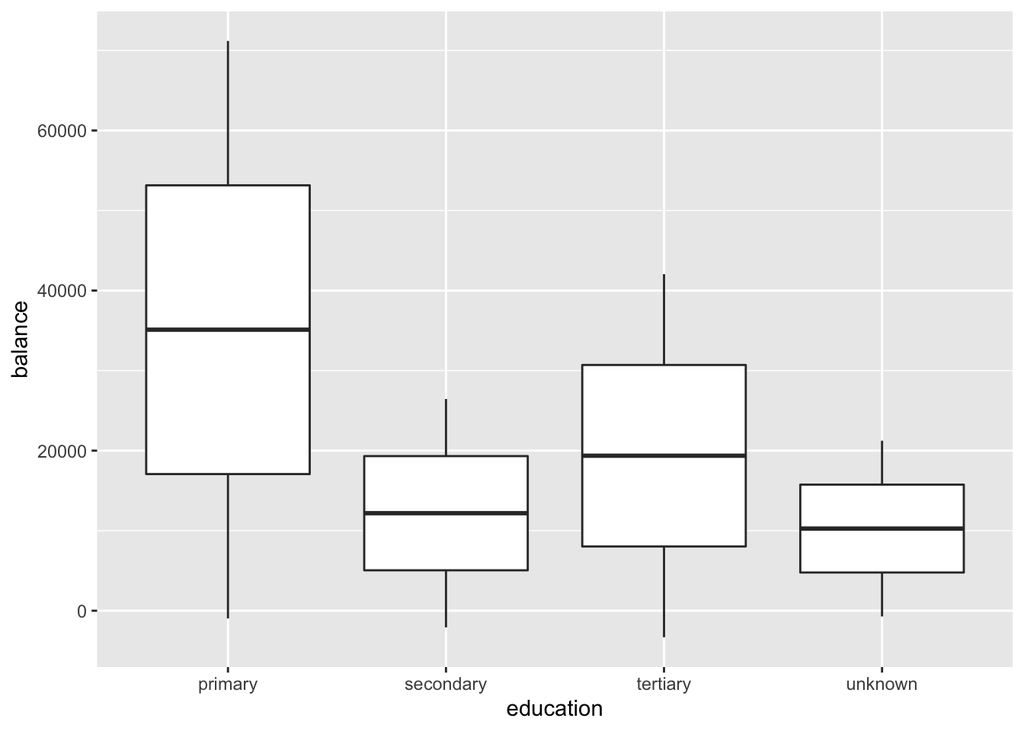

```r
ggplot(df,aes(education,balance))+
  geom_boxplot()
```

We can see:

- The range of balance in terms of primary educated people is biggest.
- People with tertiary education tend to have a higher balance and the their maximum balance is also much higher than the secondary one.

### Finding #4

Find the relationship between duration and month

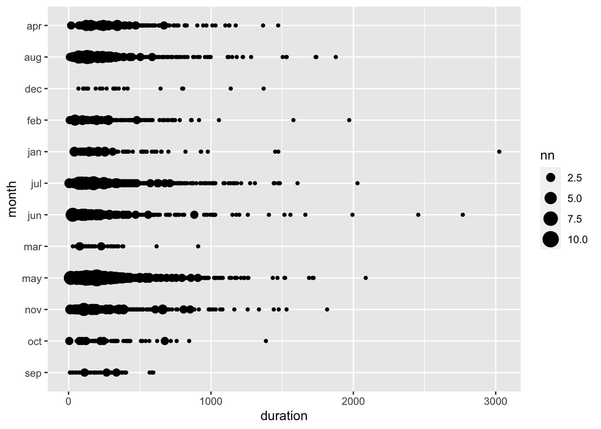

```r
group_by(bank,duration,month) %>% summarize(nn = n()) %>%
  ggplot(.)+
  geom_point(aes(duration,month,size=nn))+
  scale_y_discrete(limit = rev(levels(factor(bank$month)))) #order
## `summarise()` regrouping output by 'duration' (override with `.groups` argument)
```

We can see:

- People have a shorter contact duration in Sep and March and have a more frequency contact in May, June and July.

### Finding #5

Find the distribution of balance

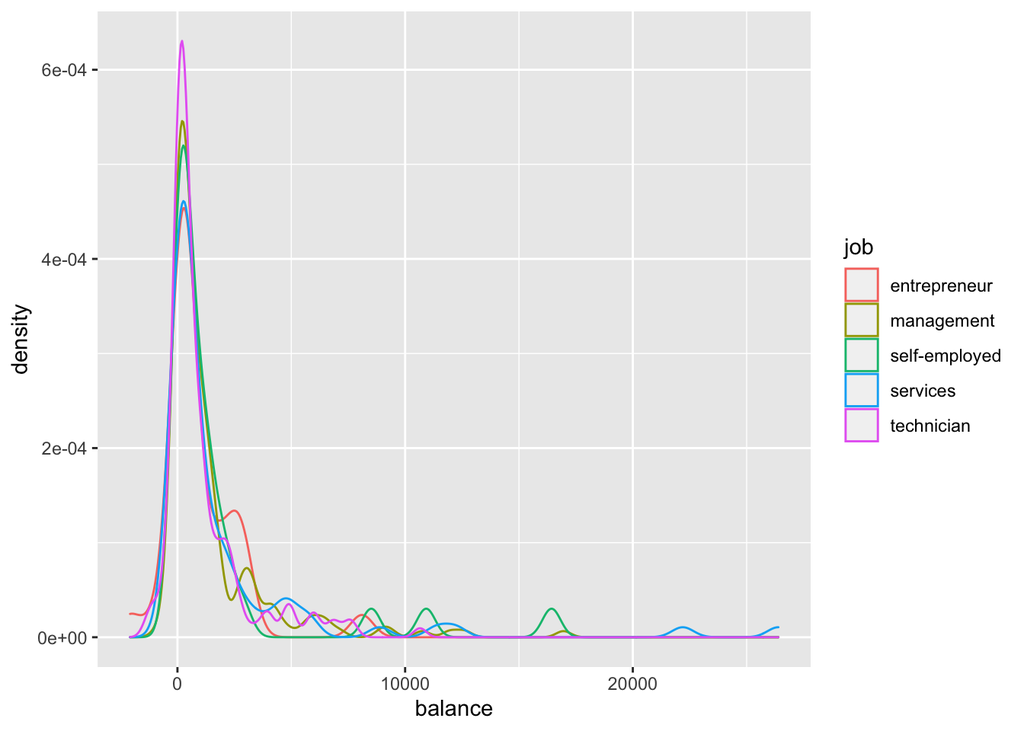

```r
filter(bank, job == c("management", "services", "technician", "entrepreneur", "self-employed")) %>%
  ggplot(aes(balance, color = job))+
  geom_density()
```

### Finding #6

Find the marital condition in different jobs except for students, the retired and unknown.

```r
distinct(bank,job)
```

```
##              job
## 1     unemployed
## 2       services
## 3     management
## 4    blue-collar
## 5  self-employed
## 6     technician
## 7   entrepreneur
## 8         admin.
## 9        student
## 10     housemaid
## 11       retired
## 12       unknown
```

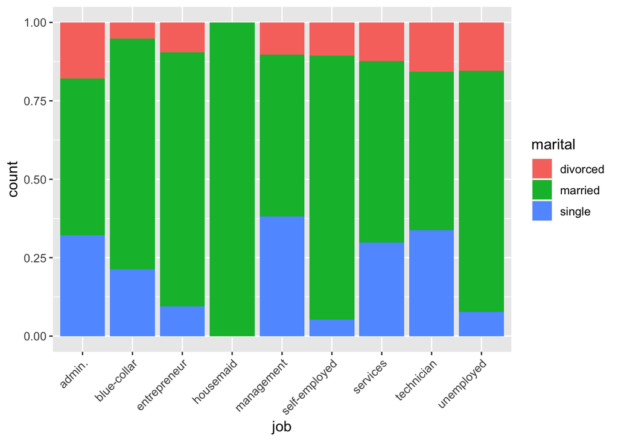

```r
filter(bank, job == c("services","unemployed","management","blue-collar","self-employed","technician","entrepreneur","admin.","housemaid")) %>%
ggplot(aes(x = job, fill = marital)) +
  geom_bar(position="fill") +
  theme(text = element_text(size=12),
        axis.text.x = element_text(angle = 45, hjust = 1))
```

We can see:

- Housemaid are all married.
- Administrators have a largest percentage of getting divorced and blue-collar has the second smallest relative probability of getting divorced.
- People in the area of management hava the largest percentage of being single.